# 台股上市櫃 Altman’s Z-Score (1968)破產預測

周育呈 e11559560532@gmail.com

2025-02-16

# 1. 前言

這是碩二上宗穎老師$\color{#EA0000}{金融機構與市場}$的小組報告，剛好是一個練習 LDA(線性區別分析) 跟評估分類模型的機會，所以多花了時間整理成一個 side project，雖然這是碩班課程的小組報告，但此篇的所有內容(R程式碼)都是我後續整理出來的，並非當初的課堂報告。

# 2. Altman’s Z-Score (1968)

我沒有直接把這篇1968年的論文翻出來看，是聽教授上完課跟參考上課的 PPT 後直接實作，所以這裡的敘述與原文無關，以下內容為我的破產預測實作方法。  
Altman 對於公開發行公司和私人公司分別給予 5 個財務比例變數，我依照公司是否發生危機事件把公司季財報標記為 2 類：違約與非違約，然後以訓練集資料做$\color{#EA0000}{線性區別分析}-\rm{Linear \, Discriminant\, Analysis(LDA)}$估計出 Altman 5 個財務比例變數的係數，用以計算測試集資料的 Z-Score，最終以 Z-Score 數值的大小去區別(預測)是否破產，以下附上當時上課的 slide。

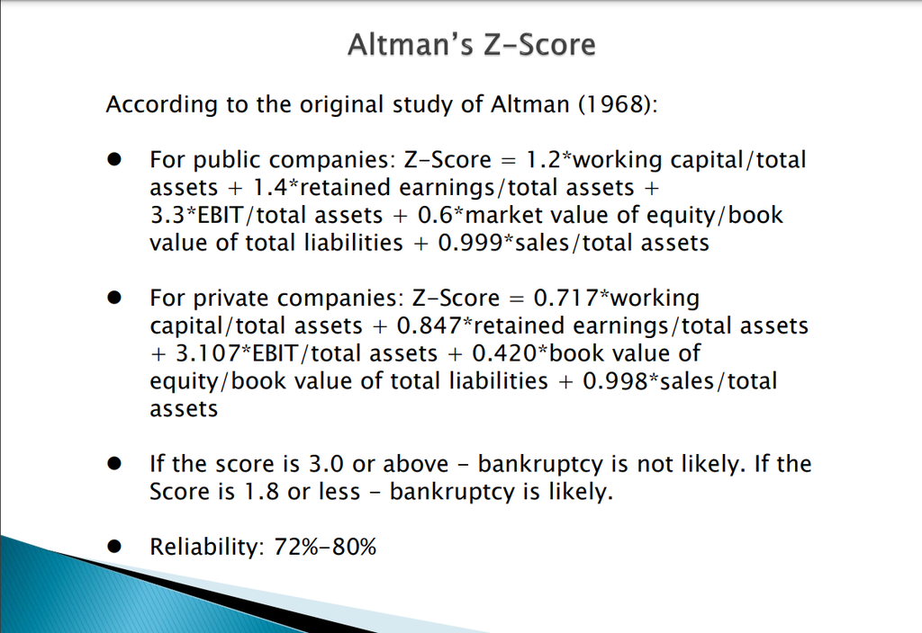

# 3. 實作流程

這節會逐步說明整個專案的實際實作流程，同時附上 R 語言程式碼與部分資料加以說明。

## 3.1 資料來源

資料來源皆為台灣經濟新報資料庫(TEJ)，違約樣本為 TEJ 所有下市、下櫃資料中有發生危機事件的公司。  
分別抓取下市下櫃公司的基本資料，資料位置為：  
$\rm{\color{#EA0000}{TEJ \, Company \, DB}}$ $\to$ $\color{#EA0000}{基本資料}$ 中的 $\rm{\color{#0072E3}{TSE舊產業名 下市日期、最近一次撤銷公開發行日、危機發生日、危機事件大類別、危機事件大類別說明、危機事件類別、 危機事件類別說明}}$  
在左上角可選擇下市、下櫃，所以有 2 組公司基本資料的檔案。  
接著抓 Z-Score 所需要的財務資料，資料位置為：  
$\rm{\color{#EA0000}{TEJ \quad IFRS \quad Finance-國際會計準則}}$ $\to$ $\rm{\color{#EA0000}{IFRS以合併為主簡表(單季)-全產業}}$ ，抓取其中的：  
$\color{#0072E3}{營運資金、資產總額、保留盈餘、稅前淨利、負債總額、季底普通股市值、營業收入淨額、流動資產、流動負債}$  
在左上角可選擇上市、上櫃、下市、下櫃，所以有 4 個財務資料檔案，資料期間為 2005/06 ~ 2022/09。  
開始前先把所有會用到的套件載入。

```r
library(readxl)
library(dplyr)
library(lubridate)
library(tidyr)
library(pROC)
library(PRROC)
library(ggplot2)
library(ggthemes)
library(MASS)
```

首先把資料匯入R語言並分別把 2 個公司基本資料與 4 個財報資料合併在一起。

```r
Company_DB_TSE <- read_excel("Company_DB下市.xlsx")
Company_DB_OTC <- read_excel("Company_DB下櫃.xlsx")
Company_DB <- rbind(Company_DB_TSE,Company_DB_OTC)
TSE_Zscore <- read_excel("上市普通股_Zscore.xlsx")
OTC_Zscore <- read_excel("上櫃普通股_Zscore.xlsx")
deTSE_Zscore <- read_excel("下市普通股_Zscore.xlsx")
deOTC_Zscore <- read_excel("下櫃普通股_Zscore.xlsx")
Z_score <- rbind(TSE_Zscore,OTC_Zscore,deTSE_Zscore,deOTC_Zscore)
```

這裡各別列出 20 筆資料，稍微看一下資料內容。

| 代號 | 名稱 | TSE舊產業名 | 下市日期 | 最近一次撤銷公開發行日 | 危機發生日 | 危機事件大類別 | 危機事件大類別說明 | 危機事件類別 | 危機事件類別說明 |
| --- | --- | --- | --- | --- | --- | --- | --- | --- | --- |
| 1113 | 永康 | M1100 水泥工業 | 1995/03/10 | 2007/02/16 | 2006/11/15 | Y | 財務危機(2006/11/15) | H | 重整(2006/11/15) |
| 1204 | 津津 | M1200 食品工業 | 2005/10/04 | 2006/06/28 | 2008/09/10 | Q | 重大財務事件(2008/09/10) | F | 掏空挪用(2008/09/10) |
| 1206 | 台鳳 | M1200 食品工業 | 2000/08/05 | 2002/08/26 | 2006/04/12 | Q | 重大財務事件(2006/04/12) | F | 掏空挪用(2006/04/12) |
| 1207 | 嘉食化 | M1200 食品工業 | 2007/04/11 | 2008/05/16 | 2008/07/23 | Y | 財務危機(2008/07/23) | D | 倒閉破產(2008/07/23) |
| 1208 | 和信興 | M1200 食品工業 | 1982/10/10 | 2002/01/23 | 1997/02/17 | Y | 財務危機(1997/02/17) | E | 繼續經營疑慮(1997/02/17) |
| 1209 | 益華 | M1200 食品工業 | 2000/11/15 | 2002/03/15 | 2005/01/05 | Q | 重大財務事件(2005/01/05) | F | 掏空挪用(2005/01/05) |
| 1212 | 中日 | M1200 食品工業 | 2005/10/28 | 2007/02/12 | 2006/10/20 | Y | 財務危機(2006/10/20) | C | 跳票擠兌(2006/10/20) |
| 1221 | 久津 | M1200 食品工業 | 2003/06/18 | 2009/11/05 | 2012/05/01 | Q | 重大財務事件(2012/05/01) | F | 掏空挪用(2012/05/01) |
| 1222 | 源益 | M1200 食品工業 | 2003/01/09 | 2003/03/28 | 2002/11/07 | Y | 財務危機(2002/11/07) | H | 重整(2002/11/07) |
| 1228 | 臺芳 | M1200 食品工業 | 2004/03/15 | 2004/06/30 | 2004/03/15 | Y | 財務危機(2004/03/15) | N | 全額下市(非5(2004/03/15) |
| 1230 | 聯成食品 | M1200 食品工業 | 2001/11/01 | 2002/04/30 | 2001/10/22 | Y | 財務危機(2001/10/22) | E | 繼續經營疑慮(2001/10/22) |
| 1262 | 綠悅-KY | M9900 其他 | 2019/10/14 | 2019/10/14 | NA | NA | NA | NA | NA |
| 1302 | 國塑 | M1300 塑膠工業 | 1990/09/16 | 1990/09/16 | 1992/02/13 | Y | 財務危機(1992/02/13) | D | 倒閉破產(1992/02/13) |
| 1306 | 合發 | M1300 塑膠工業 | 2005/10/04 | 2006/05/09 | 2008/09/10 | Q | 重大財務事件(2008/09/10) | F | 掏空挪用(2008/09/10) |
| 1311 | 福聚 | M1300 塑膠工業 | 2008/04/23 | 2008/08/14 | NA | NA | NA | NA | NA |
| 1405 | 大明 | M1400 紡織纖維 | 1989/08/15 | 2002/11/13 | 2000/02/09 | Y | 財務危機(2000/02/09) | E | 繼續經營疑慮(2000/02/09) |
| 1424 | 新東 | M1400 紡織纖維 | 1993/12/01 | 2002/08/06 | 1998/03/11 | Y | 財務危機(1998/03/11) | E | 繼續經營疑慮(1998/03/11) |
| 1425 | 福昌 | M1400 紡織纖維 | 1998/03/21 | 1999/01/19 | 1997/02/01 | Y | 財務危機(1997/02/01) | C | 跳票擠兌(1997/02/01) |
| 1427 | 鴻通 | M1400 紡織纖維 | 1986/09/09 | 1988/09/16 | NA | NA | NA | NA | NA |
| 1429 | 新奇 | M1400 紡織纖維 | 1990/09/12 | 1994/02/14 | 1989/10/28 | Y | 財務危機(1989/10/28) | E | 繼續經營疑慮(1989/10/28) |

| 代號 | 名稱 | 年/月 | 營運資金 | 資產總額 | 保留盈餘 | 稅前淨利 | 負債總額 | 季底普通股市值 | 營業收入淨額 | 流動資產 | 流動負債 |
| --- | --- | --- | --- | --- | --- | --- | --- | --- | --- | --- | --- |
| 1101 | 台泥 | 2005/06 | NA | 155862768 | 9517932 | 5794511 | 92570623 | 51989263 | 30377303 | 32139230 | 22400691 |
| 1102 | 亞泥 | 2005/06 | NA | 90435433 | 13027693 | 3650629 | 42041081 | 45045864 | 13497253 | 21057925 | 16136189 |
| 1103 | 嘉泥 | 2005/06 | NA | 31461754 | 2869936 | -204603 | 18472568 | 8710506 | 4167225 | 9296980 | 6360900 |
| 1104 | 環泥 | 2005/06 | NA | 16521794 | 1942702 | 132431 | 6684638 | 4905555 | 3290667 | 3981705 | 2384054 |
| 1108 | 幸福 | 2005/06 | NA | 9381525 | 206966 | 210914 | 5089518 | 3181241 | 2717622 | 6301398 | 3952596 |
| 1109 | 信大 | 2005/06 | NA | 6944783 | 1322296 | 235896 | 1175994 | 4084927 | 1294596 | 3049984 | 821430 |
| 1110 | 東泥 | 2005/06 | NA | 9664486 | 1819853 | 209478 | 1596268 | 4111835 | 990881 | 1145986 | 428648 |
| 1201 | 味全 | 2005/06 | NA | 13325446 | -1370010 | 143774 | 9747112 | 5465470 | 7890218 | 4599755 | 4667008 |
| 1203 | 味王 | 2005/06 | NA | 7511607 | 15606 | -115958 | 3776138 | 1904202 | 2133092 | 1674356 | 1641272 |
| 1210 | 大成 | 2005/06 | NA | 14274215 | 1049112 | 479248 | 8144814 | 4012229 | 16400377 | 7880144 | 6419158 |
| 1213 | 大飲 | 2005/06 | NA | 724953 | 83854 | 3664 | 147388 | 428950 | 321125 | 343516 | 115988 |
| 1215 | 卜蜂 | 2005/06 | NA | 3773132 | 27473 | 35754 | 1409733 | 1250620 | 5582322 | 2348492 | 1253147 |
| 1216 | 統一 | 2005/06 | NA | 208994863 | 8326416 | 3165455 | 142471593 | 50293222 | 114604070 | 54987837 | 73398514 |
| 1217 | 愛之味 | 2005/06 | NA | 9371767 | 165171 | 44725 | 5284880 | 3020885 | 2711991 | 3190435 | 3959785 |
| 1218 | 泰山 | 2005/06 | NA | 9166711 | -71464 | -104514 | 5782606 | 2251657 | 5154355 | 3196052 | 3340711 |
| 1219 | 福壽 | 2005/06 | NA | 5506539 | 73286 | 13466 | 2176592 | 1535372 | 2800892 | 2875475 | 1018505 |
| 1220 | 台榮 | 2005/06 | NA | 2750623 | -111678 | 16990 | 822558 | 1062462 | 1514045 | 1467178 | 718436 |
| 1225 | 福懋油 | 2005/06 | NA | 3693139 | -53121 | 51112 | 1748542 | 927390 | 2799972 | 1895380 | 1478359 |
| 1227 | 佳格 | 2005/06 | NA | 7206570 | 1066857 | 297039 | 2825340 | 3867062 | 4354658 | 3296213 | 1743714 |
| 1229 | 聯華 | 2005/06 | NA | 14344485 | 2762118 | 440402 | 3472852 | 7455258 | 1997992 | 3073669 | 1938475 |

## 3.2 違約公司資料處理

合併完後開始清理資料，首先取出公司基本資料(Company_DB)需要的 columns 並改為英文，同時去除已下市下櫃但無危機發生日之樣本，即無發生危機事件的公司。  
因為從 TEJ 取得的財報資料始於 2005/06 ，故選取危機發生日在 2006 年 6 月以後之樣本，之後才可從危機發生日往前抓最多 1 年的財報資料用以訓練模型。  
最後抓出危機事件大類別為 Y 的樣本，依 TEJ 說明類別 Y 為財務危機而類別 Q 為準財務危機，詳細說明可查看 [TEJ上市(櫃)基本資料](https://www.tej.com.tw/tejdoc/db-document/tw/wind.html)。

```r
Delisted <- Company_DB %>% dplyr::select(Stock_Code = 代號,
                                  Name = 名稱,
                                  Ind = TSE舊產業名,
                                  crisis_date = 危機發生日,
                                  crisis_major_cat  = 危機事件大類別,
                                  crisis_cat  = 危機事件類別) %>%
  drop_na(crisis_date) %>% mutate(crisis_date = ymd(crisis_date)) %>%
  filter(crisis_date >= "2006-06-01",
         crisis_major_cat == 'Y')
```

接著根據季財報最晚公布時間做出季財報公布日期與季財報向量，用以對應 $\rm{\color{#26a588}{Delisted}}$ 中的危機發生日，決定基準財報的時間點。

```r
fr_date  <- c()
for(a in 2005:2023){
  fr_date  <- c(fr_date ,
                    paste(a,c("-03-31","-05-15","-08-14","-11-14"),sep = ""))
}
fr_date <- ymd(fr_date)
fr_quarter  <- c()
for(a in 2005:2023){
  fr_quarter <- c(fr_quarter,paste(a,c("/03/01","/06/01","/09/01","/12/01"),sep = ""))
}
```

基準財報標記方法如下：以危機發生日最近的上個財報公布日之財報作為基準財報，後續以基準財報作為標記違約樣本之起點。

```r
Delisted$corr_qr_date <- ymd("1999-02-19")
Delisted$corr_qr  <- "A"
for(a in 1:nrow(Delisted)){
  for(b in 1:length(fr_date)){
    if(Delisted[[a,"crisis_date"]] <= fr_date[b]){
      Delisted[a,"corr_qr_date"] <- fr_date[b-1]
      Delisted[a,"corr_qr"] <- fr_quarter[b-2]
      break
    }
  }
}
```

以上述第 1 筆資料 1113 永康 為例，它的危機發生日為 $\rm{\color{#EA0000}{2006/11/15}}$ ，距離此日期最近的上個財報公布日是 $\rm{\color{#EA0000}{2006/11/14}}$ 為第三季季報， 因此 1113 永康 對應的違約樣本點以 2006 年第 3 季為基準財報，即資料中的 2006/09/01，如要標記更多樣本為違約樣本則以基準財報再往前抓，即 2006 年第 2 季、2006 年第 1 季等等，如公司已下市或其他原因無任何財報資料可使用，則放棄該樣本公司。

再從 $\rm{\color{#26a588}{Delisted}}$ 抓出需要的 columns 為新的資料框 $\rm{\color{#26a588}{Default\_df}}$ 即完成違約公司資料處理。

```r
Default_df <- Delisted %>%
  dplyr::select(Stock_Code,crisis_date,corr_qr_date,corr_qr) %>%
  mutate(corr_qr = ymd(corr_qr))
```

最後檢查一下有違約公司的基準財報是否有標記錯。

| Stock_Code | crisis_date | corr_qr_date | corr_qr |
| --- | --- | --- | --- |
| 1113 | 2006-11-15 | 2006-11-14 | 2006-09-01 |
| 1207 | 2008-07-23 | 2008-05-15 | 2008-03-01 |
| 1212 | 2006-10-20 | 2006-08-14 | 2006-06-01 |
| 1431 | 2006-06-06 | 2006-05-15 | 2006-03-01 |
| 1601 | 2008-02-03 | 2007-11-14 | 2007-09-01 |
| 1606 | 2022-04-29 | 2022-03-31 | 2021-12-01 |
| 1704 | 2015-05-29 | 2015-05-15 | 2015-03-01 |
| 1748 | 2006-10-19 | 2006-08-14 | 2006-06-01 |
| 1918 | 2008-09-04 | 2008-08-14 | 2008-06-01 |
| 2016 | 2007-05-17 | 2007-05-15 | 2007-03-01 |
| 2333 | 2007-06-20 | 2007-05-15 | 2007-03-01 |
| 2335 | 2006-08-31 | 2006-08-14 | 2006-06-01 |
| 2361 | 2016-03-29 | 2015-11-14 | 2015-09-01 |
| 2384 | 2023-08-11 | 2023-05-15 | 2023-03-01 |
| 2418 | 2011-04-15 | 2011-03-31 | 2010-12-01 |
| 2475 | 2019-12-30 | 2019-11-14 | 2019-09-01 |
| 2490 | 2006-09-25 | 2006-08-14 | 2006-06-01 |
| 2494 | 2009-03-05 | 2008-11-14 | 2008-09-01 |
| 2499 | 2021-05-31 | 2021-05-15 | 2021-03-01 |
| 2523 | 2012-08-30 | 2012-08-14 | 2012-06-01 |
| 2566 | 2010-02-25 | 2009-11-14 | 2009-09-01 |
| 2714 | 2006-06-16 | 2006-05-15 | 2006-03-01 |
| 3383 | 2022-11-15 | 2022-11-14 | 2022-09-01 |
| 3519 | 2019-08-29 | 2019-08-14 | 2019-06-01 |
| 3536 | 2023-05-11 | 2023-03-31 | 2022-12-01 |
| 3579 | 2019-08-14 | 2019-05-15 | 2019-03-01 |
| 3584 | 2017-11-29 | 2017-11-14 | 2017-09-01 |
| 4424 | 2006-08-31 | 2006-08-14 | 2006-06-01 |
| 5259 | 2019-12-13 | 2019-11-14 | 2019-09-01 |
| 6131 | 2022-09-16 | 2022-08-14 | 2022-06-01 |

[output cut: 67 more lines]

以第 7 筆股票號碼 1704 來看，危機發生日在 2015-05-29，上個財報公布日是 2015-05-15 為 2015 年第 1 季財報，故 corr_qr 為 2015-03-01，其他公司相同邏輯故基準財報無標記錯誤，接下來開始整理財報資料。

## 3.3 季財報資料處理

先把財報資料的 columns 改為英文，因財報資料中 $\bf營運資金$ 的都是 NA，所以直接用 $\bf流動資產$ 減去 $\bf流動負債$ 計算營運資金。

```r
Z_df <- Z_score %>% mutate(NWC = 流動資產 - 流動負債) %>%
  rename(Stock_Code = 代號,
         Name = 名稱,
         Date = `年/月`,
         TA = 資產總額,
         RE = 保留盈餘,
         EBIT = 稅前淨利,
         TL = 負債總額,
         MKCAP = 季底普通股市值,
         Sales = 營業收入淨額) %>%
  dplyr::select(-營運資金,-流動資產,-流動負債)
```

直接合併違約公司樣本 $\rm{\color{#26a588}{Default\_df}}$ 和財報資料 $\rm{\color{#26a588}{Z\_df}}$。

```r
fr_data <- left_join(x = Z_df, y = Default_df, by = c("Stock_Code"))
```

財報資料多少會有部分的缺失值，缺失值數量如下：  
最後 3 columns 即為沒有危機事件紀錄的財報資料，但還是有部分缺失值如 147 筆的保留盈餘(RE)。

```r
colSums(is.na(fr_data))
```

```
##   Stock_Code         Name         Date           TA           RE         EBIT
##            0            0            0            5          147            8
##           TL        MKCAP        Sales          NWC  crisis_date corr_qr_date
##            5         5956            8         3383       107394       107394
##      corr_qr
##       107394
```

缺失值處理方式採個別公司鄰近值填空，如一間公司某年第 2 季的 RE 為缺失值，先以該公司先前的 RE (從當年第 1 季往前找最近的 RE)填補，如無先前的資料可使用則以後續資料(從當年第 3 季往後找最近的 RE)填補，無資料可填補則刪除該樣本。

```r
fr_data <- fr_data %>% arrange(Stock_Code,Date) %>% group_by(Stock_Code) %>%
  fill(TA,RE,EBIT,TL,MKCAP,Sales,NWC,
       .direction = "downup") %>%
  arrange(corr_qr,Stock_Code) %>% ungroup() %>% drop_na(TA:NWC)
fr_data <- fr_data %>% mutate(Date = ymd(paste0(Date,'/01')))
```

缺失值處理完開始標記違約樣本：  
先在 $\rm{\color{#26a588}{fr\_data}}$ 中新增 1 個 column：Default 用以標記是否為違約樣本，再依公司有無危機事件紀錄分為 2 個 data.frame。  
無危機事件紀錄的 $\rm{\color{#26a588}{fr\_data\_nonDefault}}$ Default 全為 ‘N’，而有危機事件紀錄的 $\rm{\color{#26a588}{fr\_data\_Default}}$ 根據上述標記違約樣本的方法，寫一個以基準財報為起點，往回標記 n 筆季財報為違約樣本的函數 $\rm{\color{#c935d3}{Default\_func}}$。  
這裡先只以標記基準財報作為違約樣本，即 $\rm{\color{#c935d3}{Default\_func}}$ 的 pre_nQ 設為 1。

```r
fr_data$Default <- 'N'
fr_data_Default <- fr_data %>% filter(!is.na(corr_qr))
fr_data_nonDefault <- fr_data %>% filter(is.na(corr_qr))

Default_func <- function(Default_fr, pre_nQ){
  tool_default <- data.frame()
  Default_fr <- Default_fr %>% arrange(Date)
  for(a in unique( Default_fr$Stock_Code )){
    tool_data <- Default_fr %>% filter(Stock_Code == a)
    if(min(tool_data$Date) > unique(tool_data$corr_qr) ){
      tool_data$Default <- "N"
      next
    }
    default_row <- max(which(tool_data$corr_qr >= tool_data$Date))

    if(nrow(tool_data) > pre_nQ & (default_row+1) > pre_nQ ){
      tool_data[(default_row-pre_nQ+1):(default_row),'Default'] <- "Y"
    }else{
      tool_data$Default <- "Y"
    }
    tool_default <- rbind(tool_default, tool_data)

  }
  return(tool_default)
}

fr_data_Default <- Default_func(Default_fr = fr_data_Default, pre_nQ = 1)
```

最後再把無危機事件紀錄的資料合併起來，即可準備做線性區別分析(LDA)。

```r
LDA_data <- rbind(fr_data_Default,fr_data_nonDefault)
```

## 3.4 線性區別分析

把整理完的財報轉變為 Altman(1968) 的 5 個財務比例變數，再以 2016 年為分界點分為訓練集和測試集。  
最後把變數做標準化，開始執行線性區別分析。

```r
LDA_raw <- LDA_data %>% transmute(Date = Date,
                                    Default = Default,
                                    x1 = NWC/TA,
                                    x2 = RE/TA,
                                    x3 = EBIT/TA,
                                    x4 = MKCAP/TL,
                                    x5 = Sales/TA)
LDA_train <- LDA_raw %>% filter(Date <= "2015-12-01") %>% filter(x4 != Inf)
LDA_train <- LDA_train %>% mutate_if(is.numeric,~ .-mean(.)/sd(.))
lda_model <- lda(Default ~ x1+x2+x3+x4+x5 ,data = LDA_train)
lda_model
```

```
## Call:
## lda(Default ~ x1 + x2 + x3 + x4 + x5, data = LDA_train)
##
## Prior probabilities of groups:
##            N            Y
## 0.9990708399 0.0009291601
##
## Group means:
##           x1           x2         x3       x4         x5
## N -0.2661744  0.002232089 -0.1534038 7.624948 -0.8371486
## Y -2.0042406 -3.150695267 -0.3019574 2.087373 -0.9488453
##
## Coefficients of linear discriminants:
##              LD1
## x1 -1.3478587716
## x2 -0.2907607199
## x3 -3.8274121757
## x4 -0.0004309021
## x5 -0.5100377737
```

模型訓練完後，依照模型係數計算測試集資料的 Altman’s Z-score，後續用以評估分類模型。  
由於 MASS::lda 在計算的時候會把輸入的資料做標準化，因此模型輸出的 x1 ~ x5 係數是負的。

```r
LDA_test <- LDA_raw %>% filter(Date > "2015-12-01") %>%
  dplyr::select(-Date) %>% mutate_if(is.numeric,~ .-mean(.)/sd(.))
LDA_test <- LDA_test %>% mutate(Zscore = coef(lda_model)[1]*x1 +
                                  coef(lda_model)[2]*x2 +
                                  coef(lda_model)[3]*x3 +
                                  coef(lda_model)[4]*x4 +
                                  coef(lda_model)[5]*x5) %>% arrange(Default, Zscore)
```

## 3.4 分類模型評估

透過 $\rm{PRROC}$ 套件計算二元分類模型最常見的 ROC Curve 與它的 AUC，並直接透過套件視覺化結果。

```r
PRROCE_roc <- roc.curve(scores.class0 = LDA_test %>% filter(Default == 'Y') %>% pull(Zscore),
                 scores.class1 = LDA_test %>% filter(Default == 'N') %>% pull(Zscore),
                 curve = TRUE)
PRROCE_roc$auc
```

```
## [1] 0.988349
```

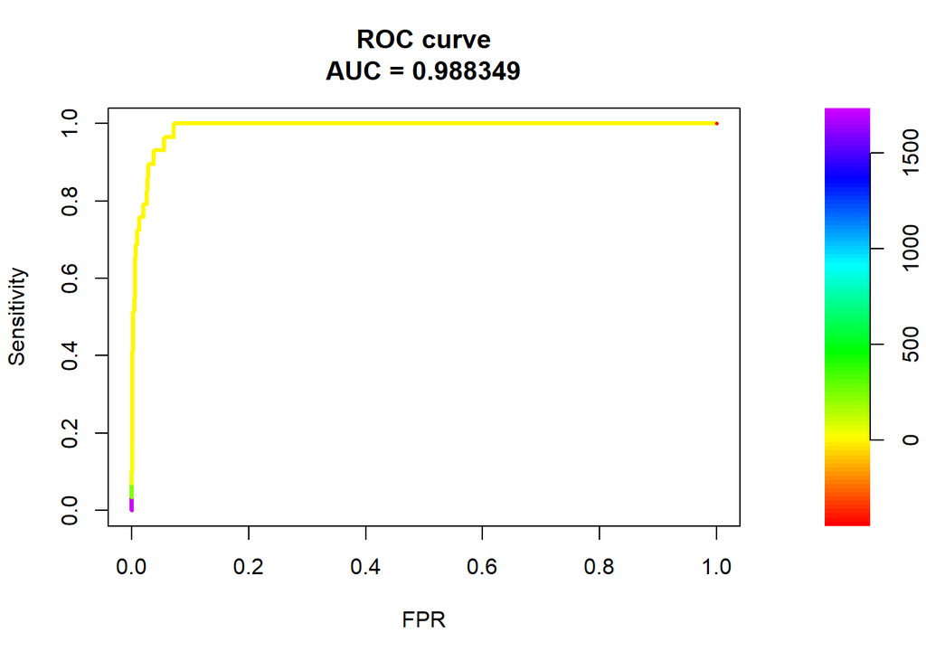

```r
plot(PRROCE_roc,legend = TRUE)
```

可看到 AUC(ROC) 高達 0.988，模型的預測表現相當好，快趨近於完美模型了，但這是由於測試集資料中有大量的陰性樣本(無違約財報樣本)，也就是測試集有嚴重的類別不平衡(imbalanced)問題，導致 AUC(ROC) 有過度樂觀的結果，其原因出在 FPR 即 ROC Curve 的 X 軸上：
$$\rm{False\; Positivity\;
Rate}=\frac{FP}{N}=\frac{FP}{FP+\color{red}{TN}}$$
由於測試集中有大量的陰性樣本，導致 $\rm{\color{red}{TN}}$ 會非常大，稀釋了 FPR 的數值。
以當前的測試集 $\rm{\color{#26a588}{LDA\_test}}$ 為例，陽性樣本與陰性樣本分別有：

```r
table(LDA_test$Default)
```

```
##
##     N     Y
## 47819    29
```

當在計算 ROC Curve 數值時，一個樣本被正確分類為陽性後 Y 軸也就是 Recall(TPR) 會上升 $\frac{1}{29}$，但如果被錯誤分類為陽性，X 軸(FPR)只會增加 $\frac{1}{47819}$，也就是樣本被錯誤預測為陽性帶來影響遠低於正確預測，進而造成 AUC(ROC) 過度樂觀的結果[^1]。

因此面對類別不平衡的資料會建議使用 PR(Precision Recall) Curve：

```r
PRROCE_pr <- pr.curve(scores.class0 = LDA_test %>% filter(Default == 'Y') %>% pull(Zscore),
                scores.class1 = LDA_test %>% filter(Default == 'N') %>% pull(Zscore),
                curve = TRUE)
PRROCE_pr$auc.integral
```

```
## [1] 0.1062288
```

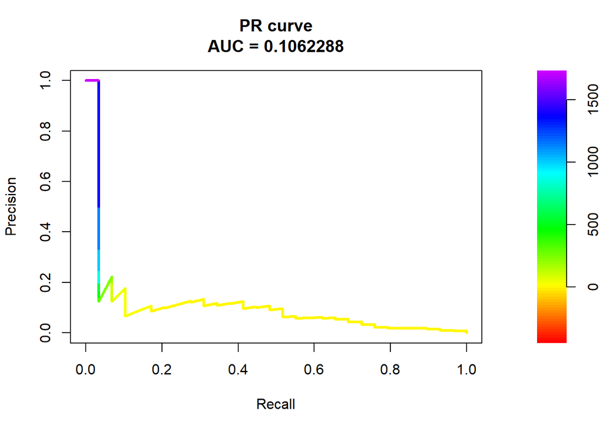

```r
plot(PRROCE_pr,legend = TRUE)
```

模型的 AUC(PR) 比起 AUC(ROC) 數值很低僅有 0.106 遠低於 0.5，雖說 PR Curve 與 ROC Curve 都是邊界為 $1*1$ 的線圖，但兩種線圖有不同的基準線：Baseline，也就是隨機分類器(random classifier)在兩種線圖的計算方式不同，在 ROC Curve 中 Baseline 都會是 $45^{\circ}$ 的對角線並不會因類別平衡程度而改變，即 AUC(ROC) 都會是 0.5，因此可直接透過模型的 AUC(ROC) 大小判斷分類模型的預測能力。
而 PR Curve 的會因測試集的類別平衡程度有不同的 Baseline，故在評估模型的 AUC(PR) 需考慮 Baseline 的大小[^2]，其計算方式為陽性樣本的占比，以當前的測試集 $\rm{\color{#26a588}{LDA\_test}}$ 的 Baseline(PR)：
$$\rm{PR\;Curve\;Baseline=\frac{P}{N+P}=\frac{29}{29+47819}}=0.0006060859$$
由於資料的類別極度不平衡，Baseline(PR) 趨近於 0，而從倍數的角度上來看模型的 AUC(PR) 是隨機分類器的 174 倍，可看到模型是有一定的違約預測能力。

最後使用 $\rm{pROC}$ 套件計算透過 Youden Index 決定模型的最佳閾值(Threshold)，和在最佳閾值下之各項模型指標。

```r
pROC_roc <- roc(response = LDA_test$Default, predictor = LDA_test$Zscore,quiet = TRUE)
pROC_indicator <- coords(pROC_roc,x = 'best',ret = 'all', best.method="youden")
```

|  | threshold | specificity | sensitivity | accuracy | tn | tp | fn | fp | npv | ppv | fdr | fpr | tpr | tnr | fnr | 1-specificity | 1-sensitivity | 1-accuracy | 1-npv | 1-ppv | precision | recall | youden | closest.topleft |
| --- | --- | --- | --- | --- | --- | --- | --- | --- | --- | --- | --- | --- | --- | --- | --- | --- | --- | --- | --- | --- | --- | --- | --- | --- |
| threshold | 0.7664343 | 0.9283758 | 1 | 0.9284192 | 44394 | 29 | 0 | 3425 | 1 | 0.0083961 | 0.9916039 | 0.0716242 | 1 | 0.9283758 | 0 | 0.0716242 | 0 | 0.0715808 | 0 | 0.9916039 | 0.0083961 | 1 | 1.928376 | 0.00513 |

模型指標說明可參考 $\rm{pROC::coords}$ 的 [Rdocumentation](https://www.rdocumentation.org/packages/pROC/versions/1.18.5/topics/coords) 下方的 Available coordinates。  
但 $\rm{pROC::}coords$ 的 youden 應該是計算錯了，需要在 -1 變成 0.928376，可參考[好豪 (´･ω･`)](https://haosquare.com/roc-curve-best-cutoff/)的優質文章。

上述的圖是直接透過 $\rm{PRROC}$ 套件畫的，最後我手動計算 ROC 與 PR Curve 的數值，再用 $\rm{ggplot2}$ 重新視覺化較詳細的圖。

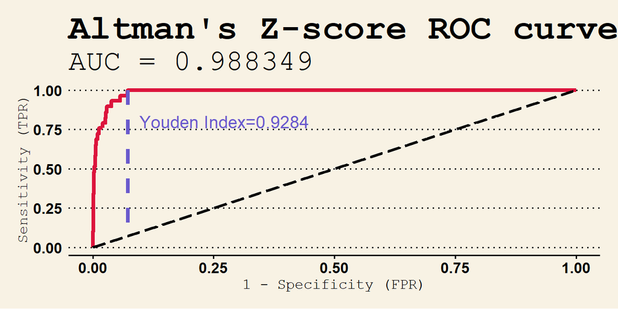

```r
curve_data <- LDA_test %>% arrange(desc(Zscore)) %>% dplyr::select(Default,Zscore) %>%
    mutate(TPR = cumsum(Default == "Y")/nrow(LDA_test %>% filter(Default == 'Y')),
           FPR = cumsum(Default == "N")/nrow(LDA_test %>% filter(Default == 'N')),
           Precision = cumsum(Default == "Y")/row_number(),
           roc_base = row_number() / n(),
           Youden_index = TPR - FPR,
           F1_score = 2*Precision*TPR/(Precision+TPR)) %>%
    add_row(Default = 'Y',
            Zscore = LDA_test %>% pull(Zscore) %>% max(),
            TPR = 0,
            FPR = 0,
            Precision = 1,
            roc_base = 0,Youden_index = 0,F1_score = 0,
            .after = 0)
# ROC
ggplot(data = curve_data) +
    geom_line(aes(x = FPR,y = TPR),linewidth =1.5,color = '#DC143C')+
    geom_line(aes(x = roc_base,y = roc_base),linetype = 'longdash',linewidth =1)+
    labs(title = "Altman's Z-score ROC curve ",
         subtitle = paste0('AUC = ',round( PRROCE_roc$auc,digits = 6)),
         x = '1 - Specificity (FPR)',
         y = 'Sensitivity (TPR)')+
    annotate(geom = 'segment',
             x = curve_data[['roc_base']][which.max(curve_data$Youden_index)],
             y = curve_data[['TPR']][which.max(curve_data$Youden_index)],
             xend = curve_data[['roc_base']][which.max(curve_data$Youden_index)],
             yend = curve_data[['roc_base']][which.max(curve_data$Youden_index)],
             col = '#6A5ACD',linewidth = 1.5,linetype = 'dashed')+
    annotate(geom = 'text',
             x = curve_data[['roc_base']][which.max(curve_data$Youden_index)]+0.2,
             y = 0.8,
             label = paste0('Youden Index=',round(max(curve_data$Youden_index),digits = 4 )),
             col = '#6A5ACD',size = 5)+
    theme_wsj()+
    theme(axis.title=element_text(size=12))
```

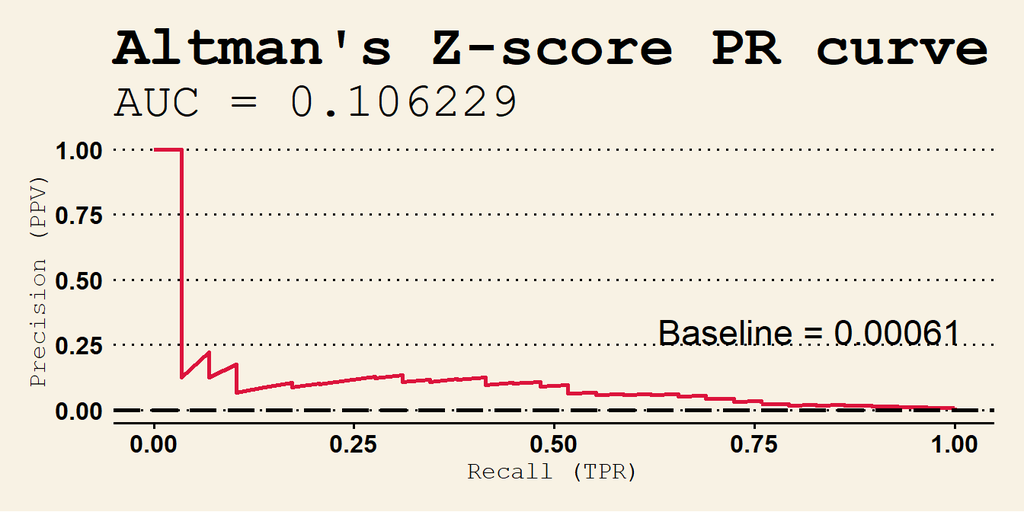

```r
# PR
ggplot(data = curve_data) +
    geom_line(aes(x = TPR,y = Precision),linewidth =1,color = '#DC143C')+
    geom_hline(yintercept = nrow(curve_data %>% filter(Default == 'Y'))/nrow(curve_data),
               linetype = 'longdash', linewidth = 1)+
    labs(title = "Altman's Z-score PR curve ",
         x = 'Recall (TPR)',
         y = 'Precision (PPV)',
         subtitle = paste0('AUC = ',round( PRROCE_pr$auc.integral,digits = 6)) )+
    annotate(geom = 'text',x = 0.82,y = 0.3,
             label = paste0('Baseline = ',
                            round(nrow(LDA_test %>% filter(Default == 'Y'))/nrow(LDA_test),
                                  digits = 5) ),
             col = 'black',size = 6)+
    theme_wsj()+
    theme(axis.title=element_text(size=12))
```

# 4. Altman_Zscore

我依照實作流程寫了一個函數：Altman_Zscore，可一次執行完 3. 實作流程 的步驟，並可針對部分內容作調整，這節說明 Altman_Zscore 的 Arguments 與回傳內容。  
Altman_Zscore 的程式碼會放在[這個 Rmarkdown](https://tarocity.github.io/Altman_code.html)。

```r
Altman_Zscore(TEJ_db, TEJ_qr, fill_na = TRUE, Category  = c('Y'), Pre_nQ = 1, Benchmark_Date = "2015-12-01")
```

## 4.1 Arguments

1. TEJ_db  
   輸入從 TEJ 抓下來後合併的公司基本資料，即上述的 $\rm{\color{#26a588}{Company\_DB}}$。
2. TEJ_qr  
   輸入從 TEJ 抓下來後合併財的報資料，即上述的 $\rm{\color{#26a588}{Z\_score}}$。
3. fill_na  
   輸入 TRUE 財報資料採個別公司鄰近值填空，否則採直接刪除有 NA 值之樣本。
4. Category  
   輸入 c(‘Y’)、c(‘Q’) 或 c(‘Y’,‘Q’)，決定以哪種 危機事件大類別 標記違約樣本。
5. Pre_nQ  
   輸入正整數決定以基準財報為起點，往回標記幾筆季財報為違約樣本。
6. Benchmark_Date  
   輸入日期字串決定日期分界點，分界點以前為訓練集以後為測試集。

## 4.2 Value

Altman_Zscore 會回傳 list，內容包含：

1. df  
   df 中有 3 個 data.frame，分別為訓練集(Train)、測試集(Test)和兩個線圖的資料(Curve)。
2. LDA.model  
   LDA.model 為 $\rm{MASS::lda}$ 訓練完 LDA 模型的資料。
3. ROC  
   ROC 中包含 AUC 數值(ROC.AUC)、Youden Index 決定的模型最佳閾值(Threshold)、在最佳閾值下之各項模型指標(Coordinates)和 ROC Curve(Plot)。
4. PR  
   PR 中包含 AUC 數值(PR.AUC)、基準線數值(Baseline)、PR Curve(Plot)。
5. Conf_Mat  
   Conf_Mat 為在 Youden Index 決定的模型最佳閾值(Threshold)下的混淆矩陣。

# 5. 模型預測結果

這節透過 Altman_Zscore 函數探討在不同的條件下模型的預測能力，分為不同違約樣本數量、NA 值處理、危機事件種類。

## 5.1 實作流程

先複製 3. 實作流程 的條件，檢查函數的結論是否跟上述一樣，後續再進行其他條件比較。

```r
Model_5.1 <- Altman_Zscore(TEJ_db = Company_DB,TEJ_qr = Z_score,Pre_nQ = 1)
Model_5.1$Conf_Mat
```

```
##          Actual
## Predicted     Y     N
##         Y    29  3425
##         N     0 44394
```

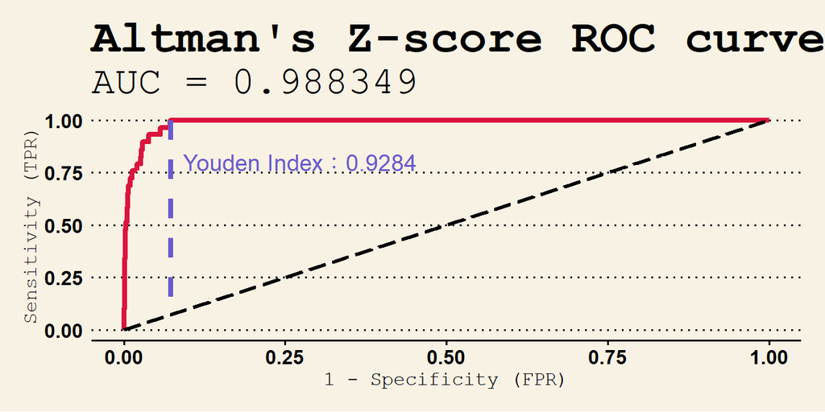

```r
Model_5.1$ROC$Plot
```

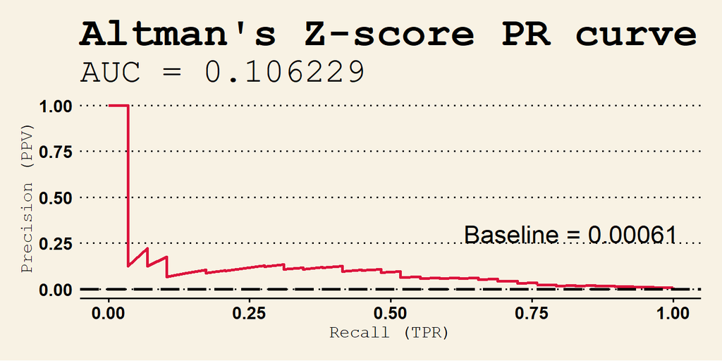

```r
Model_5.1$PR$Plot
```

## 5.2 約樣本數量

調整違約樣本數量，改以標記基準財報往前共 4 筆財報為違約樣本，即共 1 年的財報資料為違約樣本。

```r
Model_5.2 <- Altman_Zscore(TEJ_db = Company_DB,TEJ_qr = Z_score,Pre_nQ = 4)
Model_5.2$Conf_Mat
```

```
##          Actual
## Predicted     Y     N
##         Y    93  4116
##         N    12 43627
```

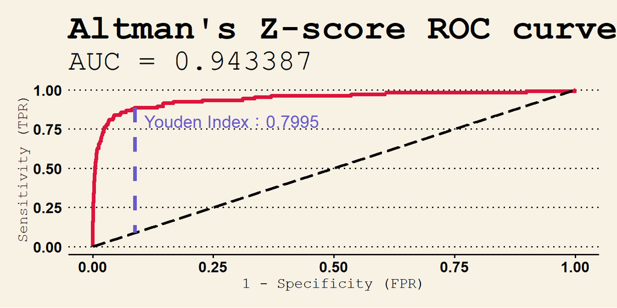

```r
Model_5.2$ROC$Plot
```

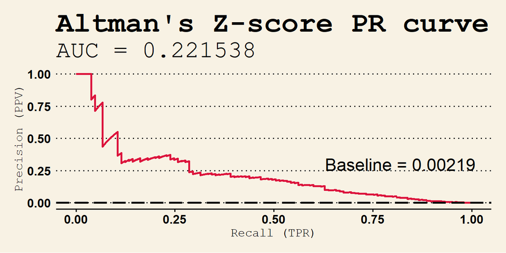

```r
Model_5.2$PR$Plot
```

從混淆矩陣可看到測試集陽性樣本確實上升，從 29 筆上升至 105筆，而 AUC(ROC) 從 0.988 下降到 0.943，AUC(PR) 則從 0.106 提升到 0.221 ，上升幅度明顯大於 AUC(ROC) 的下降程度，如果考慮到 Baseline 從倍數的角度來看，模型的 AUC(PR) 仍是隨機分類器的 100 倍。  
提升違約樣本數量模型的預測表現仍然不錯，且從違約樣本的角度上來看模型應更實用，從當前財報資料預測到下個財報公佈日會有危機事件，變成當前財報資料後 1 年內會有危機事件發生，可有更多時間做預警。

## 5.3 NA 值處理

```r
Model_5.3 <- Altman_Zscore(TEJ_db = Company_DB,TEJ_qr = Z_score,Pre_nQ = 4,fill_na = FALSE)
Model_5.3$Conf_Mat
```

```
##          Actual
## Predicted     Y     N
##         Y    56  3957
##         N    19 42569
```

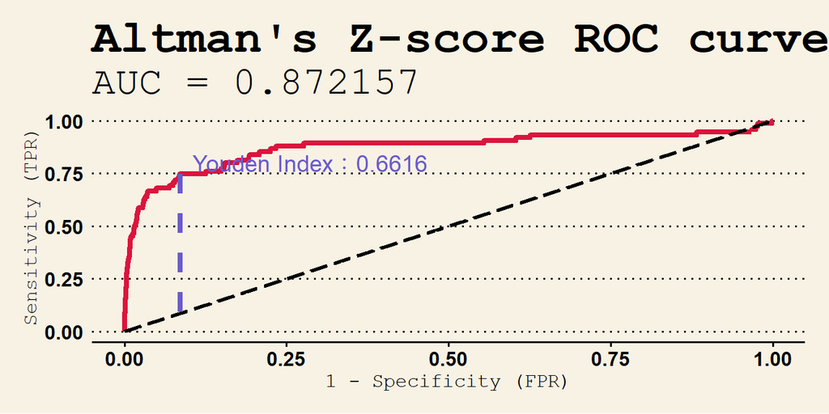

```r
Model_5.3$ROC$Plot
```

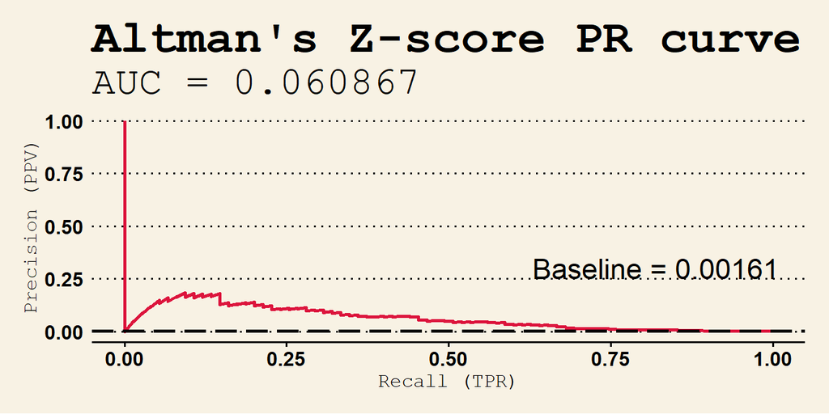

```r
Model_5.3$PR$Plot
```

如在清理財報資料時把有 NA 值樣本直接刪除，測試集陽性樣本數量從 105 筆降低到 75 筆，但不論 AUC(ROC) 或 AUC(PR) 都比採各別公司鄰近值填空來的差，故認為直接把財報缺失值刪除不是清理財報數據的好方法。

## 5.4 危機事件種類

```r
Model_5.4 <- Altman_Zscore(TEJ_db = Company_DB,TEJ_qr = Z_score,Pre_nQ = 4,Category  = c('Y','Q'))
Model_5.4$Conf_Mat
```

```
##          Actual
## Predicted     Y     N
##         Y   156  8051
##         N    48 39593
```

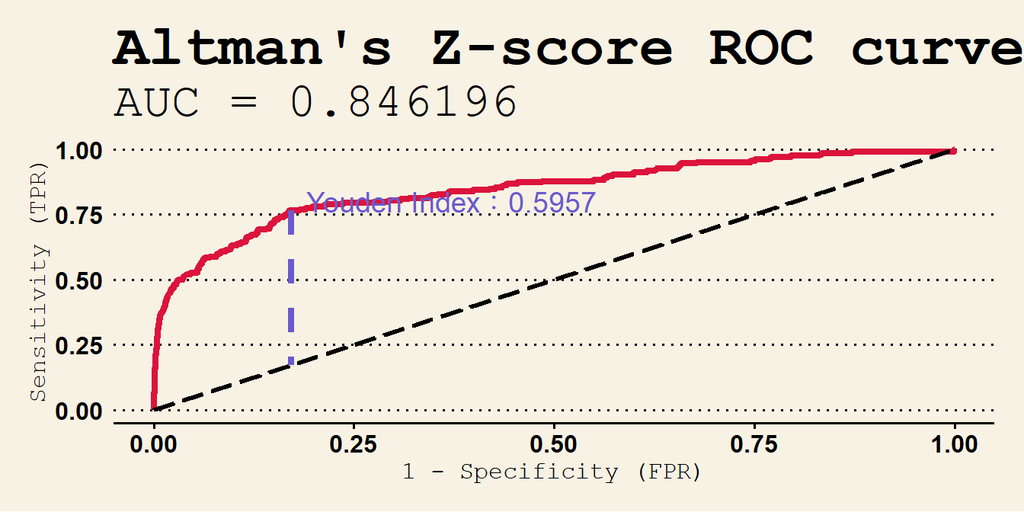

```r
Model_5.4$ROC$Plot
```

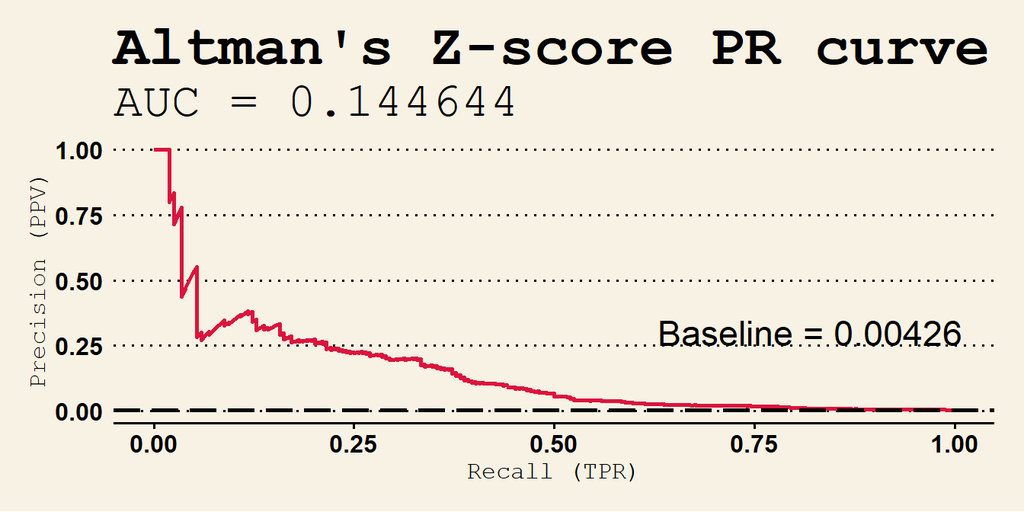

```r
Model_5.4$PR$Plot
```

如果把 非實質財務危機 也納入違約樣本的定義，雖說違約樣本數量提高了，但模型 AUC(ROC)、AUC(PR) 都沒表現較好。  
從[TEJ說明文件](https://www.tej.com.tw/tejdoc/db-document/tw/wind.html)看也滿合理的，非實質財務危機中的事件不全是財務上出問題，例如有銀行緊縮和公司遭掏空挪用等，這都是無法從財報上反映出來與預測的，故非實質財務危機放入違約樣本後以財報作為變數，模型預測效果變差也滿符合直覺的。

# 6. 總結

## 6.1 結論

如開頭提到的，這篇 side project 原本是碩二上宗穎老師$\color{#EA0000}{金融機構與市場}$的小組報告，這節課的內容主要是關於各種違約模型的介紹跟實作，Altman’s Z-Score 的報告是要我們以 Altman 的變數用 LDA 建模後畫 ROC Curve 跟計算型一、型二錯誤。  
因此這篇內容沒有像平常的機器學習一樣做 k-fold cross-validation 去比較哪種分類模型或哪些特徵效果最好，是直接以時間做切割分為訓練集合測試集，還有一點比較特別的是我需要自己標註樣本，而不是在蒐集樣本的同時樣本已經是分類過的了，所以在5. 模型預測結果 我是討論透過不同樣本標記方法對模型預測效果的影響。  
而評估分類模型時通常會因不同事件或需求選取不同指標，或者團隊討論完後直接選擇指標，而這篇專案沒有訓練其他分類模型來做比較，因此我選取最普遍的 ROC Curve 與評估類別不平衡常用的 PR Curve，其他常見的還有 Gain Curve、Lift Curve、$\rm{f_1\, score}$ 和偏重 TPR 的 $\rm{f_\beta\, score}$，這些指標就留給下次練習其他分類器和使用類別較平衡的資料吧。

就以本篇專案來說，我認為從基準財報往回標記 4 個季報單比標記基準財報，模型預測與實用性效果來的更好，且缺失值不應直接刪除而是選擇方法填補上模型表現會較好。

## 6.2 結尾

其實這篇 side project 是重新寫的，原本的 RMarkdown 在碩二上上這堂課時就已經完成了，但那時這堂課還有他報告([KMV model](https://tarocity.github.io/DTD%E8%A8%88%E7%AE%97.html))跟碩論要忙所以就匆匆的寫完了，沒時間好好整理程式碼跟了解分類模型的評估方法，所以原本的內容還滿混亂的(尤其是分類模型評估那部分)；後來碩士畢業後決定往數據分析、量化交易方面求職，加上在軍中有時間看機器學習基礎的書[^3]，在更了解 ML 的知識後決定退伍後決定把這篇專案翻出來重新整理，應該有改了超過一半的內容，我知道這篇專案以機器學習的標準還有點距離，但我也準備好了自己的學習地圖，現在的首要目標是找到相關工作。  
最後如果對這篇內容有疑問或者有錯誤可以透過 email 聯絡我，也謝謝你看到這。  
2025-02-16

[^1]: [机器学习之类别不平衡问题 (2) —— ROC和PR曲线](https://zhuanlan.zhihu.com/p/34655990)
[^2]: [What is “baseline” in precision recall curve](https://stats.stackexchange.com/questions/251175/what-is-baseline-in-precision-recall-curve)、[The baseline for Precision-Recall curve: A Bayesian approach](https://itnext.io/the-baseline-for-precision-recall-curve-a-bayesian-approach-1611c690607)、[Precision - Recall Curve, a Different View of Imbalanced Classifiers](https://sinyi-chou.github.io/classification-pr-curve/)
[^3]: [機器學習的統計基礎：深度學習背後的核心技術](https://www.books.com.tw/products/0010907137?gad_source=1&gclid=CjwKCAiAtsa9BhAKEiwAUZAszbpTpValwr7FoJyWMq7nIs_vlfr2TKnEORG7YvquPHZ6FPquagwFPRoCiDEQAvD_BwE)